# Домашняя работа №3

*Парфенова Ангелина, 162*

*16 Октября 2019*

## Анализ предикторов доверия в России

**Содержательная гипотеза**. Предположительно, доверие людям в России зависит от веры в то, что люди являются скорее честными, в то, что люди помогают, а также предположительно возраста и их места жительства. Так, взрослые могут скорее больше доверять людям, чем молодые, а жители деревни больше доверять людям в целом, чем жители больших городов. Также, предположительно, присутствует эффект взаимодействия между местом жительства респондента и верой в то, что люди склонны помогать: жители деревни более склонны думать о людях, как помогающих, что может привести к большему доверию.

**Статистическая гипотеза**: R квадрат равен нулю, все коэффициенты при предикторах равны нулю в генеральной совокупности, константа равна нулю в генеральной совокупности.

Для начала загрузим все необходимые пакеты и базу данных для анализа

```r
library(foreign)
library(lmtest)
library(car)
library(effects)
library(ggplot2)
library(colourpicker)
library(reshape2)
library(kableExtra)
library(knitr)
library(broom)
mydata <- read.spss(
  file = "ESS4e04_5.sav",
  use.value.labels = F,
  use.missings = T,
  to.data.frame = T)
```

*Анализироваться будут следующие переменные: ppltrst(A8), pplfair(A9), pplhlp(A10), trstlgl(B4), trstplc(B5), trstplt(B6), trstep(B7), trstun(B8), trstprt(B9), trstprl(B10)*.

Я выбрала как *зависимую* - переменную доверия людям так, как она измерена по 11-бальной шкале, а значит ее можно считать интервальной. Посмотрим как закодирована Россия в наборе данных.

```r
levels(mydata$cntry)
```

```
##  [1] "BE" "BG" "CH" "CY" "CZ" "DE" "DK" "EE" "ES" "FI" "FR" "GB" "GR" "HR"
## [15] "HU" "IE" "IL" "LV" "NL" "NO" "PL" "PT" "RO" "RU" "SE" "SI" "SK" "TR"
## [29] "UA"
```

```r
mydata.RU <- subset(mydata, cntry == "RU")
```

Посмотрим основные статистики относительно зависимой переменной: **среднее** и **стандартное отклонение**.

```r
mean(mydata.RU$ppltrst, na.rm = T)
```

```
## [1] 3.941365
```

```r
sd(mydata.RU$ppltrst, na.rm = T)
```

```
## [1] 2.656544
```

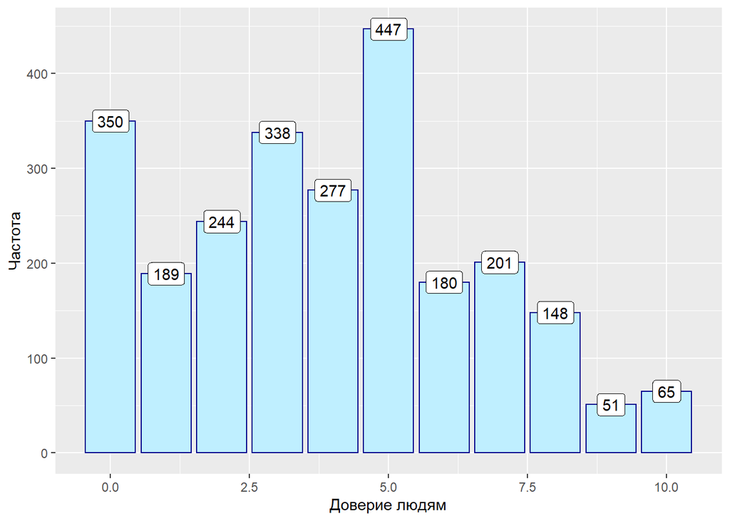

```r
ggplot(mydata.RU, aes(x=ppltrst))+
  geom_bar(fill = "#BFEFFF", colour = "darkblue")+
  geom_label(stat = "count", aes(y = stat(count), label = stat(count)))+
  xlab("Доверие людям") +
  ylab("Частота")
```

Гистограмма была выбрана по следующим причинам: **во первых** - это было требование первого домашнего задания :) , **во вторых** - это наглядное представление функции плотности вероятности доверия людям, построенное по Российской выборке.

Посмотрим среднее значение доверия людям у мужчин и женщин.

```r
mean(mydata.RU$ppltrst [mydata.RU$gndr == 1], na.rm = T)
```

```
## [1] 3.764585
```

```r
mean(mydata.RU$ppltrst [mydata.RU$gndr == 2], na.rm = T)
```

```
## [1] 4.055519
```

Таким образом, среднее доверие людям среди россиян равно 3.7645855

Срееднее доверие среди россиянок равно 4.0555188

```r
dispers<-aov(mydata.RU$ppltrst ~ as.factor(mydata.RU$gndr))
coeff.table <- summary(dispers)
```

*Разница средних в группах по полу являются значимой*

```r
coef.table <- broom::tidy(dispers)
Table1 <-knitr::kable(coef.table, format="html", digits=2)
kableExtra::kable_styling(Table1, bootstrap_options=c("hover", "striped", "condensed"))
```

| term | df | sumsq | meansq | statistic | p.value |
| --- | --- | --- | --- | --- | --- |
| as.factor(mydata.RU$gndr) | 1 | 50.25 | 50.25 | 7.14 | 0.01 |
| Residuals | 2488 | 17515.19 | 7.04 | NA | NA |

```r
t.test(
  mydata.RU$ppltrst [mydata.RU$gndr == 1],
  mydata.RU$ppltrst [mydata.RU$gndr == 2],
  paired = FALSE,
)
```

```
##
##  Welch Two Sample t-test
##
## data:  mydata.RU$ppltrst[mydata.RU$gndr == 1] and mydata.RU$ppltrst[mydata.RU$gndr == 2]
## t = -2.7191, df = 2202.9, p-value = 0.006597
## alternative hypothesis: true difference in means is not equal to 0
## 95 percent confidence interval:
##  -0.50075666 -0.08111009
## sample estimates:
## mean of x mean of y
##  3.764585  4.055519
```

В базе переменные пола и места жительства представлены как “numeric”, необходимо их превратить в тип “factor” - то есть категориальные.

```r
mydata.RU$gndr_f <- Recode(
  var =  mydata.RU$gndr,
  recodes = "1=1; 2=2; else=NA",
  as.factor=T)
mydata.RU$domicil_f <- Recode(
  var =  mydata.RU$domicil,
  recodes = "1=1; 2=2; 3=3; 4=4; 5=5; else=NA",
  as.factor=T)
```

**Распределение зависимой переменной**

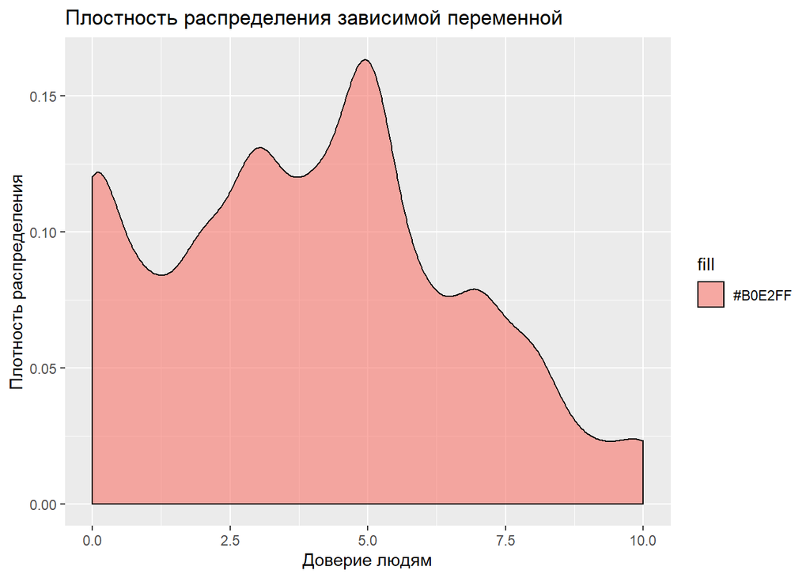

```r
ggplot(mydata.RU, aes(ppltrst, fill = "#B0E2FF"))+
  geom_density(alpha=0.6) +
xlab("Доверие людям") +
  ylab("Плотность распределения")+
  ggtitle("Плостность распределения зависимой переменной")
```

Данный тип графика был выбран по причине того, что зависимая переменная является интервальной. Также имеет смысл проверить является ли распределение приближенным к нормальному.

## Совместные распределения (2 варианта визуализации)

Давайте посмотрим совместные распределения некоторых переменных, которые мы хотим включить в модель: доверие людям(зависимая), вера в честность людей, вера в то, что люди помогают. Для этого на одном графике изобразим функции плотности распределения этих переменных (все они относятся к интервальному типу).

Следующий тип графика сможет наглядно изобразить распределения сразу трех переменных в координатном пространстве, что значительно облегчает работу по контролированию на критерий нормальности распределения каждой переменной по одной.

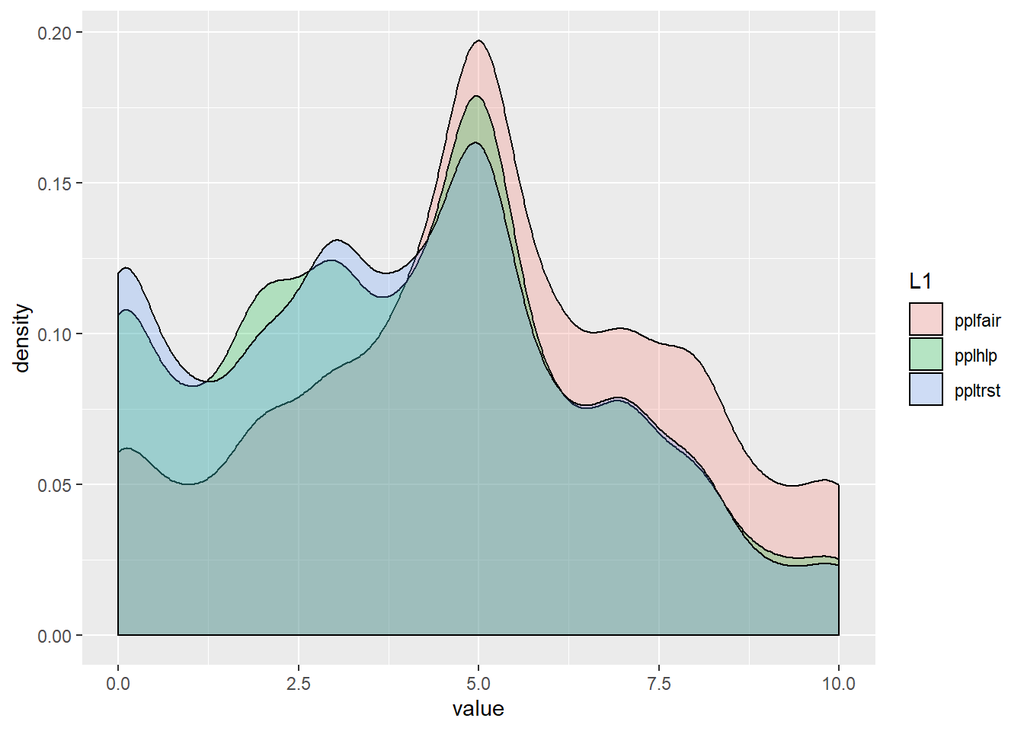

```r
x <- list(ppltrst=mydata.RU$ppltrst,pplfair=mydata.RU$pplfair,pplhlp=mydata.RU$pplhlp)
data<- melt(x)
ggplot(data,aes(x=value, fill=L1)) + geom_density(alpha=0.25)
```

Следующий тип графика поможет узнать существует ли наглядная разница между уровнем доверия в разных местах проживания, до потдверждения статистической значимости этих различий.

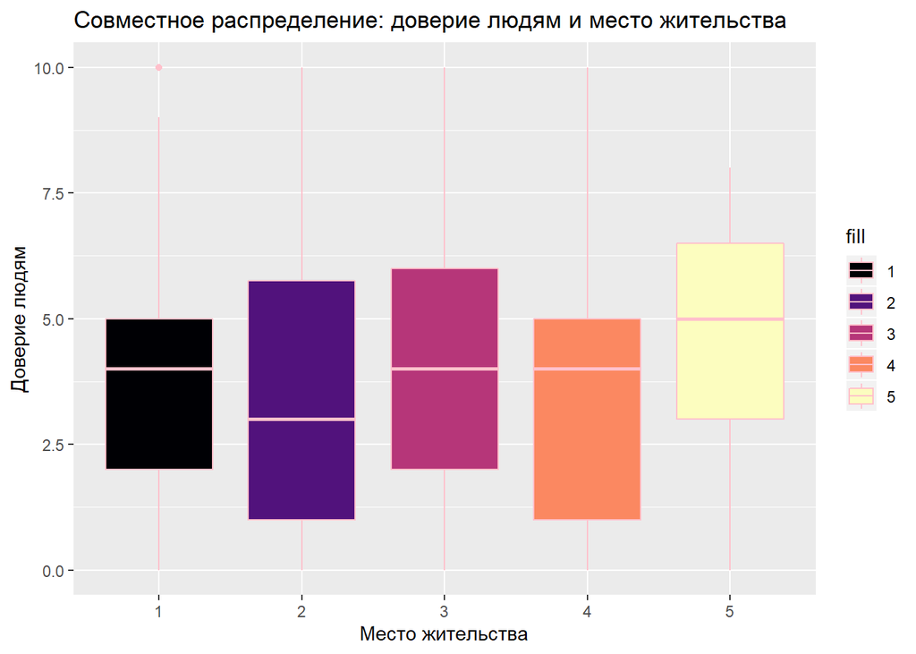

```r
dat.clean1<- na.omit(subset(mydata.RU, select = c(ppltrst, domicil)))

ggplot(dat.clean1, aes(as.factor(domicil), fill = "red", ppltrst))+
  geom_boxplot(color = "pink", aes (fill = as.factor(domicil)))+
  scale_fill_viridis_d(option = "magma")+
ggtitle("Совместное распределение: доверие людям и место жительства")+
  xlab("Место жительства")+
ylab("Доверие людям")
```

Построим первую регрессионную модель с независимыми переменными: вера в честность людей, вера в помощь людей, возраст, место жительства и пол.